# IODS course project

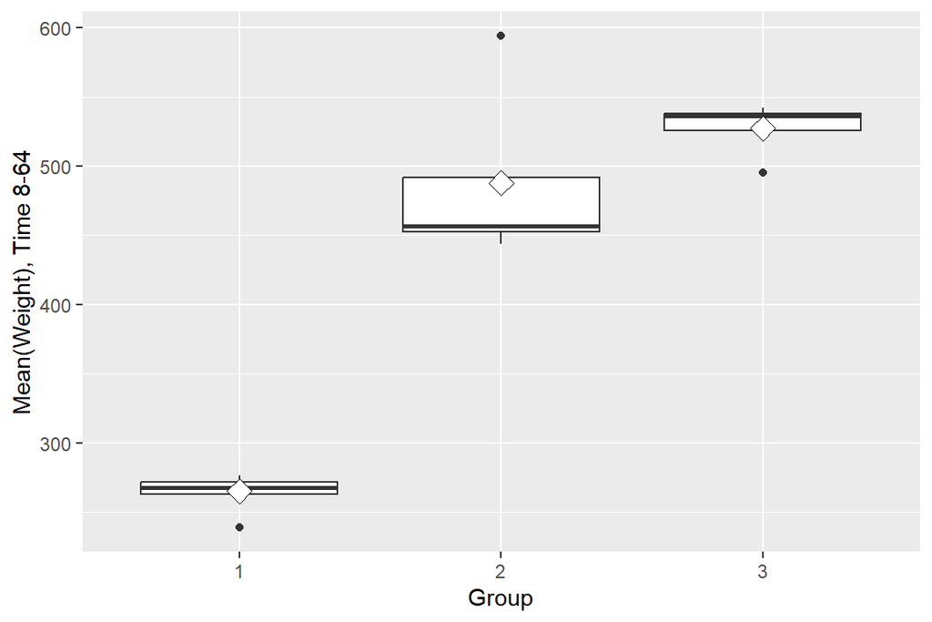

```r
# draw a box plot of the mean versus Group
ggplot(RATSL8S, aes(x = Group, y = Mean)) +
  geom_boxplot() +
  stat_summary(fun = "mean", geom = "point", shape=23, size=4, fill = "white") +
  scale_y_continuous(name = "Mean(Weight), Time 8-64")
```

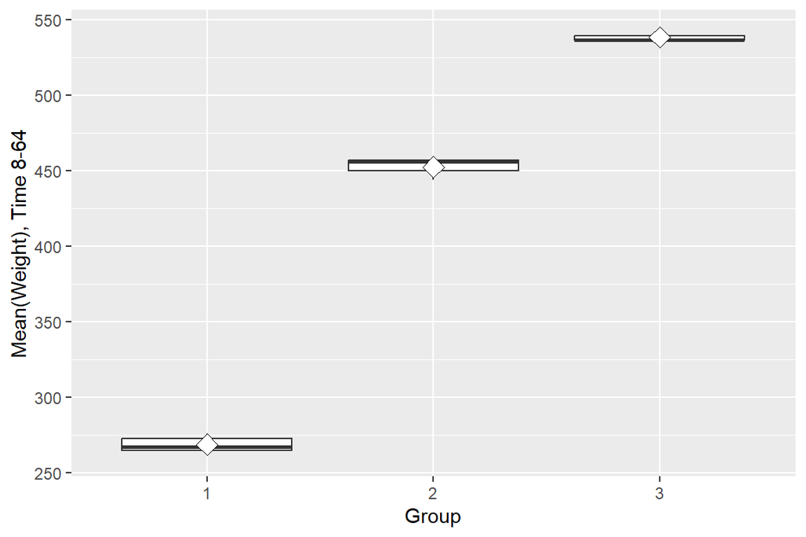

```r
# Create a new data by filtering the outlier and adjust the ggplot code the draw the plot again with the new data
RATSL8S1 <- RATSL %>%
  filter(Time > 1) %>%
  group_by(Group, ID) %>%
  summarise( Mean = mean(Weight) ) %>%
  filter((Group == 1 & Mean > 250) | (Group == 2 & Mean < 550) | (Group == 3 & Mean > 500)) %>%
  ungroup()
# draw the plot again with the new data
ggplot(RATSL8S1, aes(x = Group, y = Mean)) +
  geom_boxplot() +
  stat_summary(fun = "mean", geom = "point", shape=23, size=4, fill = "white") +
  scale_y_continuous(name = "Mean(Weight), Time 8-64")
```

```r
# Testing


# Perform a two-sample t-test
t.test(Mean ~ Group, data = filter(RATSL8S1, Group != 3), var.equal = TRUE)
```

```
##
##  Two Sample t-test
##
## data:  Mean by Group
## t = -44.305, df = 8, p-value = 7.434e-11
## alternative hypothesis: true difference in means between group 1 and group 2 is not equal to 0
## 95 percent confidence interval:
##  -193.2012 -174.0845
## sample estimates:
## mean in group 1 mean in group 2
##        268.7571        452.4000
```

```r
t.test(Mean ~ Group, data = filter(RATSL8S1, Group != 2), var.equal = TRUE)
```

```
##
##  Two Sample t-test
##
## data:  Mean by Group
## t = -77.715, df = 8, p-value = 8.377e-13
## alternative hypothesis: true difference in means between group 1 and group 3 is not equal to 0
## 95 percent confidence interval:
##  -277.5065 -261.5125
## sample estimates:
## mean in group 1 mean in group 3
##        268.7571        538.2667
```

```r
t.test(Mean ~ Group, data = filter(RATSL8S1, Group != 1), var.equal = TRUE)
```

```
##
##  Two Sample t-test
##
## data:  Mean by Group
## t = -18.235, df = 4, p-value = 5.32e-05
## alternative hypothesis: true difference in means between group 2 and group 3 is not equal to 0
## 95 percent confidence interval:
##  -98.94088 -72.79246
## sample estimates:
## mean in group 2 mean in group 3
##        452.4000        538.2667
```

```r
# Add the baseline from the original data as a new variable to the summary data
RATS <- read.table("https://raw.githubusercontent.com/KimmoVehkalahti/MABS/master/Examples/data/rats.txt", header = TRUE, sep = '\t')
RATSL8S2 <- RATSL8S %>%
  mutate(Baseline = RATS$WD1)


# Fit the linear model with the mean as the response
fit <- lm(Mean ~ Baseline + Group, data = RATSL8S2)
fit
```

```
##
## Call:
## lm(formula = Mean ~ Baseline + Group, data = RATSL8S2)
##
## Coefficients:
## (Intercept)     Baseline       Group2       Group3
##     33.1637       0.9251      34.8575      23.6753
```

```r
# Compute the analysis of variance table for the fitted model with anova()
anova(fit)
```

```
## Analysis of Variance Table
##
## Response: Mean
##           Df Sum Sq Mean Sq   F value   Pr(>F)
## Baseline   1 253625  253625 1859.8201 1.57e-14 ***
## Group      2    879     439    3.2219  0.07586 .
## Residuals 12   1636     136
## ---
## Signif. codes:  0 '***' 0.001 '**' 0.01 '*' 0.05 '.' 0.1 ' ' 1
```

Interpretation:

- For analyzing the data and finding patterns, first of all, it is useful to graphically display the data. From the initial plot, we see that weight of all rats has increased over the 64 weeks of the study. In addition, rats with higher weight at the beginning , have got higher weight throughout the study.
- To decrease the effects of variables with very high means or variances, we should standardize the variables. The new standardized plot dose not show the same straight positive direction of rats’ weight over time. On the contrary, it shows that some rats’ weight has decreased or remained without significant change during the experiment.
- In order to show average profiles for each treatment group along with some indication of the variation of the observations at each time point, we drawled the mean profile. From the mean profiles, we see that the average weight of rats in group 1 has been less than rats in group 2 and 3 during the 64 weeks.
- A possible alternative to plotting the mean profiles is to graph side-by-side box plots of the observations at each time point. From the boxplot we can easily find the outliers, and in the next stage, we remove the outliers to get more accurate result.
- Besides graphical presentations, we need to apply t-test to assess any difference between the groups. As t-test is a two sample test, we applied it on each pairs of groups. The result shows:
  - difference in means between group 1 and group 2 is not equal to 0
  - difference in means between group 1 and group 3 is not equal to 0
  - difference in means between group 2 and group 3 is not equal to 0
- From ANOVA test, we see that the baseline RATS is strongly related to the RATS values taken after experiment has begun, but there is still no evidence of an experiment difference even after conditioning on the baseline value.

## Exercise 2

```r
library(lme4)
```

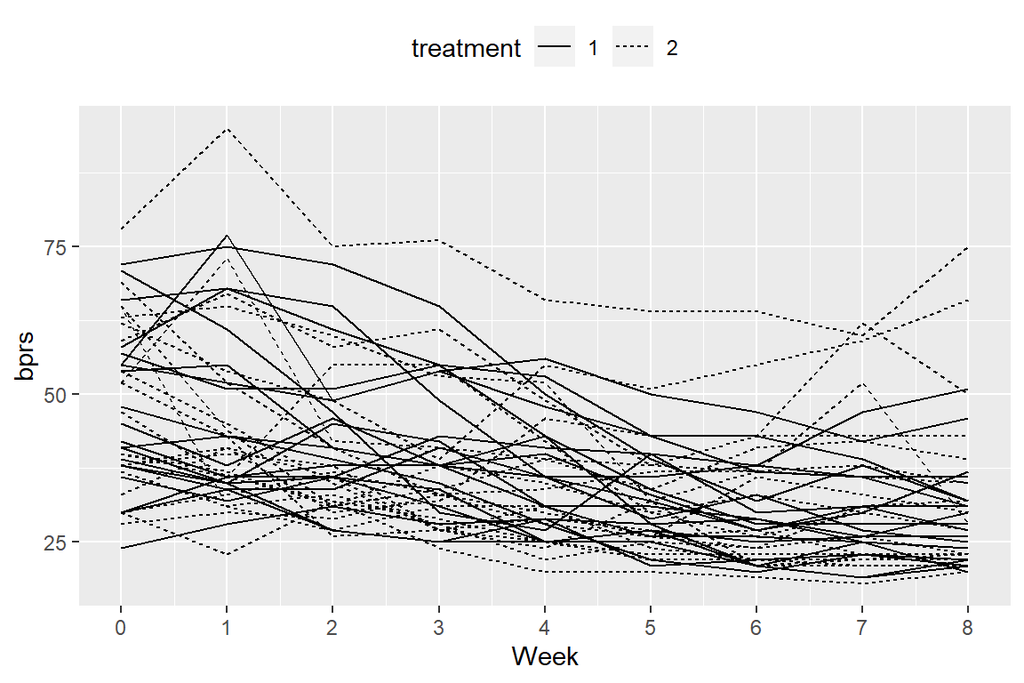

```r
library(stats)


# Plot the BPRSL data
ggplot(BPRSL, aes(x = week, y = bprs, group = interaction(treatment, subject), linetype = treatment)) +
  geom_line() +
  scale_x_continuous(name = "Week", breaks = seq(0, 8, 1)) +
  scale_y_continuous(name = "bprs") +
  theme(legend.position = "top")
```

```r
# create a regression model BPRSL_reg
BPRSL_reg <- lm(bprs ~ week + treatment, data = BPRSL )


# print out a summary of the model
summary(BPRSL_reg)
```

```
##
## Call:
## lm(formula = bprs ~ week + treatment, data = BPRSL)
##
## Residuals:
##     Min      1Q  Median      3Q     Max
## -22.454  -8.965  -3.196   7.002  50.244
##
## Coefficients:
##             Estimate Std. Error t value Pr(>|t|)
## (Intercept)  46.4539     1.3670  33.982   <2e-16 ***
## week         -2.2704     0.2524  -8.995   <2e-16 ***
## treatment2    0.5722     1.3034   0.439    0.661
## ---
## Signif. codes:  0 '***' 0.001 '**' 0.01 '*' 0.05 '.' 0.1 ' ' 1
##
## Residual standard error: 12.37 on 357 degrees of freedom
## Multiple R-squared:  0.1851, Adjusted R-squared:  0.1806
## F-statistic: 40.55 on 2 and 357 DF,  p-value: < 2.2e-16
```

```r
# Create a random intercept model
BPRSL_ref <- lmer(bprs ~ week + treatment + (1 | subject), data = BPRSL, REML = FALSE)


# Print the summary of the model
summary(BPRSL_ref)
```

```
## Linear mixed model fit by maximum likelihood  ['lmerMod']
## Formula: bprs ~ week + treatment + (1 | subject)
##    Data: BPRSL
##
##      AIC      BIC   logLik deviance df.resid
##   2748.7   2768.1  -1369.4   2738.7      355
##
## Scaled residuals:
##     Min      1Q  Median      3Q     Max
## -3.0481 -0.6749 -0.1361  0.4813  3.4855
##
## Random effects:
##  Groups   Name        Variance Std.Dev.
##  subject  (Intercept)  47.41    6.885
##  Residual             104.21   10.208
## Number of obs: 360, groups:  subject, 20
##
## Fixed effects:
##             Estimate Std. Error t value
## (Intercept)  46.4539     1.9090  24.334
## week         -2.2704     0.2084 -10.896
## treatment2    0.5722     1.0761   0.532
##
## Correlation of Fixed Effects:
##            (Intr) week
## week       -0.437
## treatment2 -0.282  0.000
```

```r
# create a random intercept and random slope model
BPRSL_ref1 <- lmer(bprs ~ week + treatment + (week | subject), data = BPRSL, REML = FALSE)


# print a summary of the model
summary(BPRSL_ref1)
```

```
## Linear mixed model fit by maximum likelihood  ['lmerMod']
## Formula: bprs ~ week + treatment + (week | subject)
##    Data: BPRSL
##
##      AIC      BIC   logLik deviance df.resid
##   2745.4   2772.6  -1365.7   2731.4      353
##
## Scaled residuals:
##     Min      1Q  Median      3Q     Max
## -2.8919 -0.6194 -0.0691  0.5531  3.7976
##
## Random effects:
##  Groups   Name        Variance Std.Dev. Corr
##  subject  (Intercept) 64.8222  8.0512
##           week         0.9609  0.9802   -0.51
##  Residual             97.4305  9.8707
## Number of obs: 360, groups:  subject, 20
##
## Fixed effects:
##             Estimate Std. Error t value
## (Intercept)  46.4539     2.1052  22.066
## week         -2.2704     0.2977  -7.626
## treatment2    0.5722     1.0405   0.550
##
## Correlation of Fixed Effects:
##            (Intr) week
## week       -0.582
## treatment2 -0.247  0.000
```

```r
# perform an ANOVA test on the two models
anova(BPRSL_ref1, BPRSL_ref)
```

```
## Data: BPRSL
## Models:
## BPRSL_ref: bprs ~ week + treatment + (1 | subject)
## BPRSL_ref1: bprs ~ week + treatment + (week | subject)
##            npar    AIC    BIC  logLik deviance  Chisq Df Pr(>Chisq)
## BPRSL_ref     5 2748.7 2768.1 -1369.4   2738.7
## BPRSL_ref1    7 2745.4 2772.6 -1365.7   2731.4 7.2721  2    0.02636 *
## ---
## Signif. codes:  0 '***' 0.001 '**' 0.01 '*' 0.05 '.' 0.1 ' ' 1
```

```r
# create a random intercept and random slope model with the interaction
BPRSL_ref2 <- lmer(bprs ~ week * treatment + (week | subject), data = BPRSL, REML = FALSE)


# print a summary of the model
summary(BPRSL_ref2)
```

```
## Linear mixed model fit by maximum likelihood  ['lmerMod']
## Formula: bprs ~ week * treatment + (week | subject)
##    Data: BPRSL
##
##      AIC      BIC   logLik deviance df.resid
##   2744.3   2775.4  -1364.1   2728.3      352
##
## Scaled residuals:
##     Min      1Q  Median      3Q     Max
## -3.0512 -0.6271 -0.0768  0.5288  3.9260
##
## Random effects:
##  Groups   Name        Variance Std.Dev. Corr
##  subject  (Intercept) 64.9964  8.0620
##           week         0.9687  0.9842   -0.51
##  Residual             96.4707  9.8220
## Number of obs: 360, groups:  subject, 20
##
## Fixed effects:
##                 Estimate Std. Error t value
## (Intercept)      47.8856     2.2521  21.262
## week             -2.6283     0.3589  -7.323
## treatment2       -2.2911     1.9090  -1.200
## week:treatment2   0.7158     0.4010   1.785
##
## Correlation of Fixed Effects:
##             (Intr) week   trtmn2
## week        -0.650
## treatment2  -0.424  0.469
## wek:trtmnt2  0.356 -0.559 -0.840
```

```r
# perform an ANOVA test on the two models
anova(BPRSL_ref2, BPRSL_ref1)
```

```
## Data: BPRSL
## Models:
## BPRSL_ref1: bprs ~ week + treatment + (week | subject)
## BPRSL_ref2: bprs ~ week * treatment + (week | subject)
##            npar    AIC    BIC  logLik deviance  Chisq Df Pr(>Chisq)
## BPRSL_ref1    7 2745.4 2772.6 -1365.7   2731.4
## BPRSL_ref2    8 2744.3 2775.4 -1364.1   2728.3 3.1712  1    0.07495 .
## ---
## Signif. codes:  0 '***' 0.001 '**' 0.01 '*' 0.05 '.' 0.1 ' ' 1
```

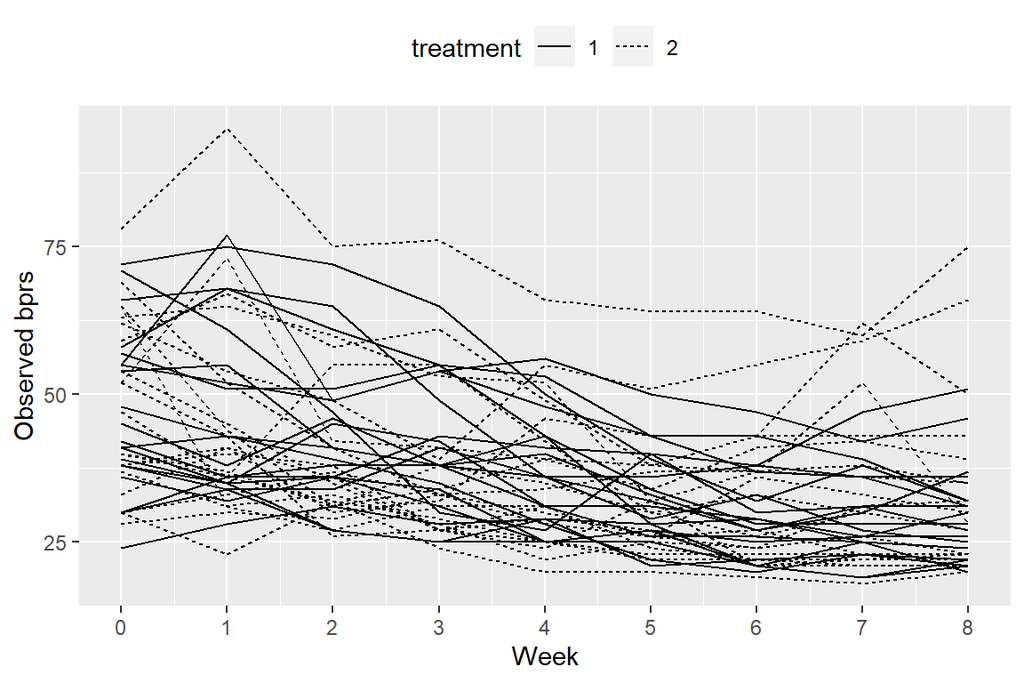

```r
# draw the plot of BPRSL with the observed bprs values
ggplot(BPRSL, aes(x = week, y = bprs, group = interaction(treatment, subject), linetype = treatment)) +
  geom_line() +
  scale_x_continuous(name = "Week", breaks = seq(0, 8, 1)) +
  scale_y_continuous(name = "Observed bprs") +
  theme(legend.position = "top")
```

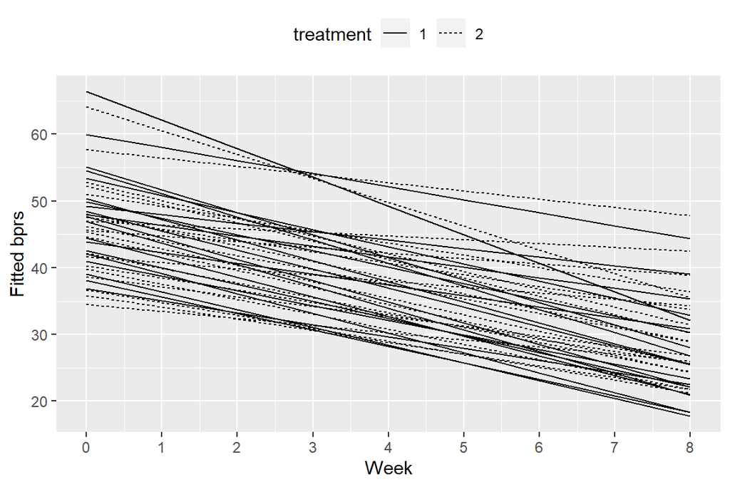

```r
# Create a vector of the fitted values
Fitted <- fitted(BPRSL_ref2)


# Create a new column fitted to BPRSL
BPRSL <- BPRSL %>%
      mutate(Fitted)


# draw the plot of BPRSL with the Fitted values of weight
ggplot(BPRSL, aes(x = week, y = Fitted, group = interaction(treatment, subject), linetype = treatment)) +
  geom_line() +
  scale_x_continuous(name = "Week", breaks = seq(0, 8, 1)) +
  scale_y_continuous(name = "Fitted bprs") +
  theme(legend.position = "top")
```

Interpretations:

- In PART II, we are looking for implementing the linear mixed effects models to figure out if there is any different between treatments in BPRS longitudinal data.
- First, we plot the data without considering the longitudinal nature of it. From the simple plot, we see that brief psychiatric rating scale (BPRS) of all subjects tend to decrease over the experiment.
- After graphical visualization, we fitted a linear model with the response variable of `bprs` and two explanatory variable of `week` and `treatment` groups. The estimation of the model for treatment two is not significant, whereas for the first treatment group (intercept) and `week` it is significant. R-squared (0.18) is not large enough. So, our model is not a quite good model.
- In the next step, we fit the random intercept model for the same two explanatory variables: `week` and `treatment`, because fitting a random intercept model allows the linear regression fit for each male to differ in intercept from other males.
- Next, we fit both the random intercept and random slope model. ANOVA helps us to analyze the variance of these two fitted models: `BPRSL_ref` and `BPRSL_ref1`. According to ANOVA result, the p-value is 0.026 which means that there is a statistically significant difference between the means of the two fitted models.
- In the last step, we reached a model that could fit the observed values. According to the fitted values plot and observed values plot, we see there is decreasing trend for the brief psychiatric rating scale (BPRS) of all subjects, however with different slopes.